# Shopify Data Science Internship Challenge

### Yun Han Xiao

*Note: This document can be found on https://hanxiao.ca/shopify.html .*

```r
library(data.table)
library(ggplot2)
library(dplyr)
library(plyr)
```

#### Question 1:

On Shopify, we have exactly 100 sneaker shops, and each of these shops sells only one model of shoe. We want to do some analysis of the average order value (AOV). When we look at orders data over a 30 day window, we naively calculate an AOV of $3145.13. Given that we know these shops are selling sneakers, a relatively affordable item, something seems wrong with our analysis.

1. Think about what could be going wrong with our calculation. Think about a better way to evaluate this data.
2. What metric would you report for this dataset?
3. What is its value?

**Answer 1 :**

*Note: although the answers are presented here, a more detailed solution and analysis for the answers to this question is presented below.*

1. Given small sample size (5000 rows) the presence of extreme outliers can skew the mean/AOV value. It is also important to note that the AOV simply state the mean order value and does not take into account the quantity of items that were purchased during each order. (More elaborated below in “step 4”)
2. If we want to keep up the meaning of AOV in the sense that we want to report a metric that illustrate the amount per order regardless of quantity, then the median value of the unmodified data set will be appropriate. Alternatively, we can also report the mean order_amount of the cleaned data set that was purged of the top 2 % most extreme outliers (see step 2 below) which yields a value very close to the median of the unmodified data.

Alternatively, we can give a value for the “average price” of each item that was sold, by simply adjusting for the total_items for each order. However, I believe that such is no longer representative of the amount an “average” order should yield, but I might be wrong.

However, I am more comfortable using the median as a replacement for the AOV

3. The median is at 284.00, the mean (AOV) of the cleaned data set is at 297.70, and finally the quantity-adjusted average price per item is 357.92

===

#### Question 2

1. How many orders were shipped by Speedy Express in total?

```sql
SELECT COUNT(OrderID)
FROM Orders
LEFT JOIN Shippers ON Shippers.ShipperID = Orders.ShipperID
WHERE ShipperName = 'Speedy Express';
```

Answer is 54

2. What is the last name of the employee with the most orders?

```sql
SELECT Employees.EmployeeID, Employees.LastName, COUNT(Orders.EmployeeID)
FROM( Orders
INNER JOIN Employees ON Employees.EmployeeID = Orders.EmployeeID)
GROUP by Orders.EmployeeID
ORDER by COUNT(Orders.EmployeeID) DESC;
```

Answer is Peacock with 40 orders

3. What product was ordered the most by customers in Germany?

```sql
SELECT OrderDetails.ProductID, COUNT(OrderDetails.ProductID)
FROM ((Orders
INNER JOIN Customers ON Orders.CustomerID = Customers.CustomerID)
INNER JOIN OrderDetails ON Orders.OrderID = OrderDetails.OrderID)
WHERE Customers.Country = 'Germany'
GROUP by OrderDetails.ProductID
ORDER by COUNT(OrderDetails.ProductID) DESC;
```

Answer: The Product of id 31 has the most order (5) amongst customers from Germany

### A more in depth look to question 1

**Step 1:** Exploratory Data Analysis

Here is an extract of our data set

```r
data <- fread("shopify_data.csv")
data %>% head()
```

| order_id | shop_id | user_id | order_amount | total_items | payment_method | created_at |
| --- | --- | --- | --- | --- | --- | --- |
| 1 | 53 | 746 | 224 | 2 | cash | 2017-03-13 12:36:56 |
| 2 | 92 | 925 | 90 | 1 | cash | 2017-03-03 17:38:52 |
| 3 | 44 | 861 | 144 | 1 | cash | 2017-03-14 4:23:56 |
| 4 | 18 | 935 | 156 | 1 | credit_card | 2017-03-26 12:43:37 |
| 5 | 18 | 883 | 156 | 1 | credit_card | 2017-03-01 4:35:11 |
| 6 | 58 | 882 | 138 | 1 | credit_card | 2017-03-14 15:25:01 |

Our target will be ‘order_amount’

Now let’s take a look at our features

```r
names(data)
```

```
[1] "order_id"       "shop_id"        "user_id"        "order_amount"   "total_items"    "payment_method" "created_at"
```

Categorical:

```r
names(data)[which(sapply(data, is.character))]
```

```
[1] "payment_method" "created_at"
```

Numeric:

```r
names(data)[which(sapply(data, is.numeric))]
```

```
[1] "order_id"     "shop_id"      "user_id"      "order_amount" "total_items"
```

By quickly checking our features we see that order_id is irrelevant to the order amount. We have numerical features shop_id, user_id, total_items and categorical features for payment_method and created_at.

```r
data %>% dim()
```

```
[1] 5000    7
```

So we have a very small data set (5000 x 7). This should already raise a flag, as the presence of extreme outliers can really mess up the mean of a small sample of data.

```r
summary(data$order_amount)
```

```
   Min. 1st Qu.  Median    Mean 3rd Qu.    Max.
     90     163     284    3145     390  704000
```

```r
sd(data$order_amount)
```

```
[1] 41282.54
```

```r
var(data$order_amount)
```

```
[1] 1704248055
```

As we can see, the standard deviation and variance are off the roof (std dev at 41 282.54$), putting this into context of sneaker sales makes no sense as 41 000 $ is the price magnitude for buying a car. As expected, the mean or AOV is at 3145.00$ which is extremely high for sneakers. Given the small size of our data set (5000 rows) and a mean that seems too high, we can hypothesize on the existence of extreme outliers strongly pulling the mean upward. This is also shown by a median of 284$, a 25th percentile at 163$ and 75th precentile at 390$, which all fall under the order of magnitude one can expect for sneakers.

Let’s to have a more visual representation of our data by doing a box plot of the order_amount to illustrate potential outliers.

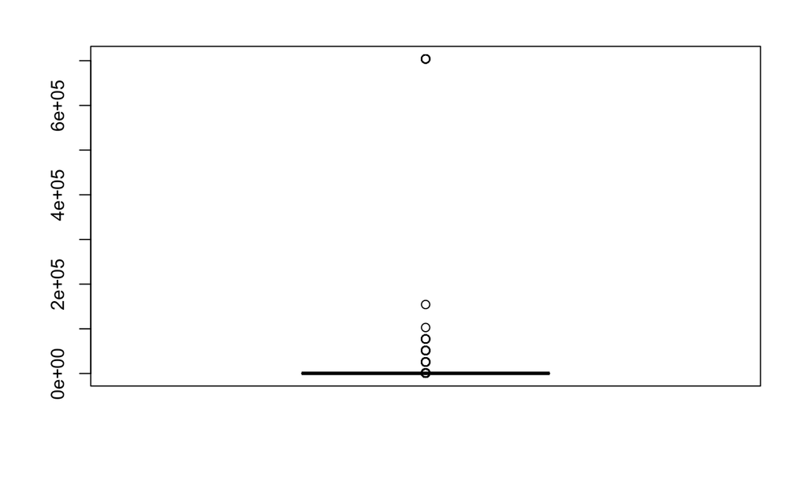

```r
boxplot(data$order_amount)
```

We can see that our outliers are so far from 75% of our data that we see it represented as a single line as opposed to a box. A key take away from this visualization is that 75% of our data has a range (height) of a line compared to the distance between the line and the points that are outliers.

Now let’s see if the order creation date, shops, payment method and/or users have any effect on the outliers, perhaps a glitch in the system on a certain day

```r
par(mfrow=c(2,2))
boxplot(data$order_amount~data$created_at, main="by created_at")
boxplot(data$order_amount~data$shop_id, main="by shop_id")
```

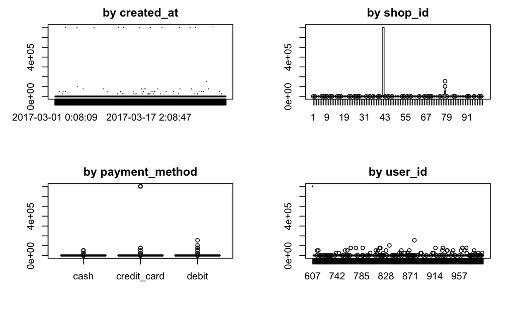

```r
boxplot(data$order_amount~data$payment_method, main="by payment_method")
boxplot(data$order_amount~data$user_id, main="by user_id")
```

**Effect of “total_items”**

One feature that we haven’t explored yet is the “total_items” which indicates the total amount of pair of sneaker that was bought during each order.

```r
summary(data$total_items)
```

```
    Min.  1st Qu.   Median     Mean  3rd Qu.     Max.
   1.000    1.000    2.000    8.787    3.000 2000.000
```

```r
quantile(data$total_items, .95)
```

```
95%
  4
```

By quickly running a summary, we realize something odd:

1. First, 75% of the orders has a quantity below 3 pairs and 95 % of the orders has a quantity of 4 pairs or less per order, which seems more or less reasonable in terms of magnitude
2. The average order quantity is 8.7 pairs of sneakers per order, which seems high considering that the products are sneakers and not some food that is consumed quickly.
3. The maximum order quantity is at 2000 pairs of shoes per order, this is extremely high, in fact if a family of 3 people made that order and all wears a new pair of shoes every day, it will take them almost 2 years!! This is extremely unlikely, in step 3 we will come back to the impact of the order size

This is illustrated through a boxplot

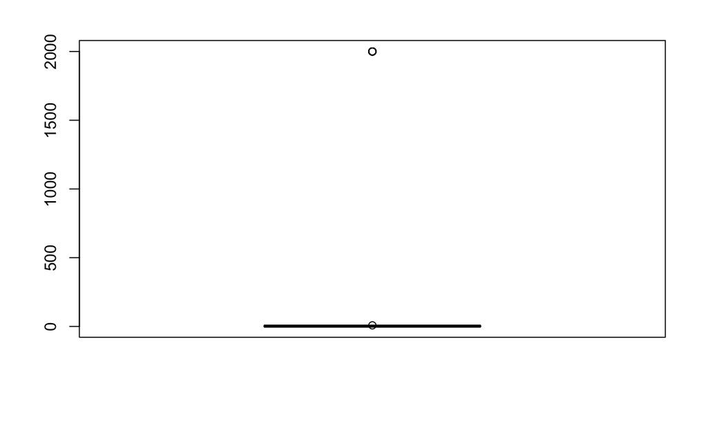

```r
boxplot(data$total_items)
```

It is important to note the effect of the feature “total_items” as they represent the quantity of each order. By quickly adjusting the mean/AOV by the quantity of item that was purchased we can obtain a mean value for each pair of sneakers.

Let’s call this metrics AIV for Average Item Value

```r
sum(data$order_amount)/sum(data$total_items)
```

```
[1] 357.9215
```

**Step 2:** Define an arbitrary set of outliers

Lets arbitrarily cut off the top 2% of the most extreme outliers Below is an extract of the copy of the data with only the outliers

| order_id | shop_id | user_id | order_amount | total_items | payment_method | created_at |
| --- | --- | --- | --- | --- | --- | --- |
| 16 | 42 | 607 | 704000 | 2000 | credit_card | 2017-03-07 4:00:00 |
| 61 | 42 | 607 | 704000 | 2000 | credit_card | 2017-03-04 4:00:00 |
| 161 | 78 | 990 | 25725 | 1 | credit_card | 2017-03-12 5:56:57 |
| 491 | 78 | 936 | 51450 | 2 | debit | 2017-03-26 17:08:19 |
| 494 | 78 | 983 | 51450 | 2 | cash | 2017-03-16 21:39:35 |
| 512 | 78 | 967 | 51450 | 2 | cash | 2017-03-09 7:23:14 |

And here is the cleaned data, which is are the orders under the 98th percentile of order_amount

| order_id | shop_id | user_id | order_amount | total_items | payment_method | created_at |
| --- | --- | --- | --- | --- | --- | --- |
| 1 | 53 | 746 | 224 | 2 | cash | 2017-03-13 12:36:56 |
| 2 | 92 | 925 | 90 | 1 | cash | 2017-03-03 17:38:52 |
| 3 | 44 | 861 | 144 | 1 | cash | 2017-03-14 4:23:56 |
| 4 | 18 | 935 | 156 | 1 | credit_card | 2017-03-26 12:43:37 |
| 5 | 18 | 883 | 156 | 1 | credit_card | 2017-03-01 4:35:11 |
| 6 | 58 | 882 | 138 | 1 | credit_card | 2017-03-14 15:25:01 |

```r
outlier %>% dim()
```

```
[1] 100   7
```

**Step 3:** Analysis on the outliers by shop_id and total_items

Now let’s try to establish a potential relationship between total_items and order_amount

```r
cor(data$order_amount, data$total_items)
```

```
[1] 0.9917469
```

As we can see the correlation between the 2 features is 0.99, this makes sense as under constant price, we expect that the order_amount increase as the customer buys more item each order.

As we can see below by decreasing order, we can visually inspect that our max for order_amount correspond to the max total_items

| order_id | shop_id | user_id | order_amount | total_items | payment_method | created_at |
| --- | --- | --- | --- | --- | --- | --- |
| 16 | 42 | 607 | 704000 | 2000 | credit_card | 2017-03-07 4:00:00 |
| 61 | 42 | 607 | 704000 | 2000 | credit_card | 2017-03-04 4:00:00 |
| 521 | 42 | 607 | 704000 | 2000 | credit_card | 2017-03-02 4:00:00 |
| 1105 | 42 | 607 | 704000 | 2000 | credit_card | 2017-03-24 4:00:00 |
| 1363 | 42 | 607 | 704000 | 2000 | credit_card | 2017-03-15 4:00:00 |
| 1437 | 42 | 607 | 704000 | 2000 | credit_card | 2017-03-11 4:00:00 |
| 1563 | 42 | 607 | 704000 | 2000 | credit_card | 2017-03-19 4:00:00 |
| 1603 | 42 | 607 | 704000 | 2000 | credit_card | 2017-03-17 4:00:00 |
| 2154 | 42 | 607 | 704000 | 2000 | credit_card | 2017-03-12 4:00:00 |
| 2298 | 42 | 607 | 704000 | 2000 | credit_card | 2017-03-07 4:00:00 |

[output cut: 94 more lines]

Now let’s do some binary encoding for every order from our data such that we obtain 2 new features:

- “outlier_by_amount”: 1 if the order_amount > 98th percentile of order_amounts else 0
- “outlier_by_item_total”: 1 if the total_items > 95th percentile else 0

```r
binary_encode_amount <- function(x){
  if (x > quantile(data$order_amount, .98)){ 1 }
  else { 0 }
}
binary_encode_items <- function(x){
  if (x > quantile(data$total_items, .95)){ 1}
  else { 0 }
}
outlier_amount<- as.vector(sapply(data$order_amount, binary_encode_amount))
outlier_items <- as.vector(sapply(data$total_items, binary_encode_items))
```

| order_id | shop_id | user_id | order_amount | total_items | payment_method | created_at | outlier_by_amount | outlier_by_item_total |
| --- | --- | --- | --- | --- | --- | --- | --- | --- |
| 1 | 53 | 746 | 224 | 2 | cash | 2017-03-13 12:36:56 | 0 | 0 |
| 2 | 92 | 925 | 90 | 1 | cash | 2017-03-03 17:38:52 | 0 | 0 |
| 3 | 44 | 861 | 144 | 1 | cash | 2017-03-14 4:23:56 | 0 | 0 |
| 4 | 18 | 935 | 156 | 1 | credit_card | 2017-03-26 12:43:37 | 0 | 0 |
| 5 | 18 | 883 | 156 | 1 | credit_card | 2017-03-01 4:35:11 | 0 | 0 |
| 6 | 58 | 882 | 138 | 1 | credit_card | 2017-03-14 15:25:01 | 0 | 0 |
| 7 | 87 | 915 | 149 | 1 | cash | 2017-03-01 21:37:57 | 0 | 0 |
| 8 | 22 | 761 | 292 | 2 | cash | 2017-03-08 2:05:38 | 0 | 0 |
| 9 | 64 | 914 | 266 | 2 | debit | 2017-03-17 20:56:50 | 0 | 0 |
| 10 | 52 | 788 | 146 | 1 | credit_card | 2017-03-30 21:08:26 | 0 | 0 |

[output cut: 990 more lines]

Now let’s consider shop_id

We are trying to illustrate the frequency of occurence of a given shop_id within the data set identified as outliers

|  | shop_id | freq |
| --- | --- | --- |
| 21 | 78 | 46 |
| 10 | 42 | 23 |
| 12 | 46 | 3 |
| 1 | 6 | 2 |
| 3 | 12 | 2 |
| 6 | 26 | 2 |
| 18 | 66 | 2 |
| 2 | 11 | 1 |
| 4 | 13 | 1 |
| 5 | 19 | 1 |

[output cut: 17 more lines]

As we can see, it seems that 69% of the outliers ((46 + 23)/100 outliers) are originated from orders made from 2 shops: shop_id == ‘78’ and shop_id == ‘42’

Now back to the cleaned data that is purged from the top 2% extreme outliers, we have

```r
summary(cleaned$order_amount)
```

```
   Min. 1st Qu.  Median    Mean 3rd Qu.    Max.
   90.0   163.0   284.0   297.7   386.0   800.0
```

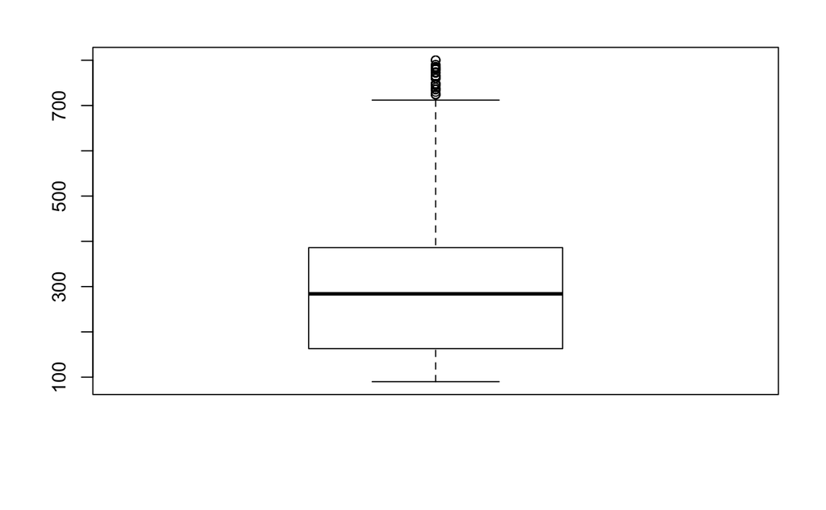

We can see that the median value has not changed, still at 284. Also, after cutting out the outliers, our mean value is very close to our median value (297.7)

**Step 4:** Contextualize our findings

In step 2, we have seen the effect of extreme outliers that constituted 2% of our data set and how by purging the extreme outliers, we obtained a mean value closer to the median value. Given the context of online stores selling sneakers, the adjusted-mean of 297.7 $ per order or median of 284 $ per order seems to have a good magnitude for sneaker prices which ranges in the hundred of dollars.

In step 3, we have also tried to briefly examine the circumstances of the extreme outliers and have found by visual inspection that 2 shops (shop_id ‘78’ and ‘42’) seems to contain 69% of the 2% of extreme outliers purged from our data set. Without more information, we can make an educated guess that these shops are some kind of wholesale or supplier whose customers are sneaker stores themselves, thus providing one possible explanation to the disproportionally huge size of order_amount and the huge quantities of items per order made from these stores.